# Pratical Machine Learning Course Project

Fabio Araujo

28 de dezembro de 2017

### **1. Abstract**

This document is the final report of the Peer-graded Assignment from the Pratical Machine Learning. The objective of this project is to predict the manner in which a group did the excercice using the data collected by devices used in their personal activity. The model to predict was performed using the “class” variable and other in the training set. At the final we choose the Random Forest Model because its better 0.9973 accuracy. The final result of the 20 different test cases follow bellow:  
B A B A A E D B A A B C B A E E A B B B

Especial thanks to: Velloso, E.; Bulling, A.; Gellersen, H.; Ugulino, W.; Fuks, H. Qualitative Activity Recognition of Weight Lifting Exercises. Proceedings of 4th International Conference in Cooperation with SIGCHI (Augmented Human ’13) . Stuttgart, Germany: ACM SIGCHI, 2013.

### **2. Background**

Using devices such as Jawbone Up, Nike FuelBand, and Fitbit it is now possible to collect a large amount of data about personal activity relatively inexpensively. These type of devices are part of the quantified self movement - a group of enthusiasts who take measurements about themselves regularly to improve their health, to find patterns in their behavior, or because they are tech geeks. One thing that people regularly do is quantify how much of a particular activity they do, but they rarely quantify how well they do it. In this project, your goal will be to use data from accelerometers on the belt, forearm, arm, and dumbell of 6 participants. They were asked to perform barbell lifts correctly and incorrectly in 5 different ways. More information is available from the website here: http://groupware.les.inf.puc-rio.br/har (see the section on the Weight Lifting Exercise Dataset). Read more: http://groupware.les.inf.puc-rio.br/har#ixzz3xsbS5bVX

### **3. Data loading, cleaning, partitioning**

#### **a) Dataset**

The training data for this project are available here: https://d396qusza40orc.cloudfront.net/predmachlearn/pml-training.csv

The test data are available here: https://d396qusza40orc.cloudfront.net/predmachlearn/pml-testing.csv

The data for this project come from this source: http://groupware.les.inf.puc-rio.br/har.

#### **b) Required packages**

```r
library(ggplot2);library(rpart);library(rpart.plot);library(caret);
library(randomForest);library(rattle);library(e1071); library(gbm);
library(corrplot)
```

#### **c) Set seed for reproducibility**

```r
set.seed(999)
```

#### **d) Data loading**

```r
# Url path
urltrain <- "https://d396qusza40orc.cloudfront.net/predmachlearn/pml-training.csv"
urltest <- "https://d396qusza40orc.cloudfront.net/predmachlearn/pml-testing.csv"
# If the training file do not exist in home dir, download it
if (!file.exists("./pml-training.csv")) {
      download.file(urltrain, destfile = "./pml-training.csv")
}
# If the testing file do not exist in home dir, download it
if (!file.exists("./pml-testing.csv")) {
      download.file(urltest, destfile = "./pml-testing.csv")
}
# Load data into R
trainRData <- read.csv("./pml-training.csv")
testRData <- read.csv("./pml-testing.csv")

dim(trainRData)
```

```
## [1] 19622   160
```

```r
dim(testRData)
```

```
## [1]  20 160
```

#### **e) Data cleaning**

```r
nzv <- nearZeroVar(trainRData, saveMetrics = T)
trainCData <- trainRData[, !nzv$nzv]
testCData <- testRData[, !nzv$nzv]

dim(trainCData)
```

```
## [1] 19622   100
```

```r
dim(testCData)
```

```
## [1]  20 100
```

```r
# remove variables that are mostly NA
onlyNA <- sapply(trainCData, function(x) mean(is.na(x))) > 0.95
trainCData <- trainCData[, onlyNA==F]
testCData <- testCData[, onlyNA==F]
dim(trainCData)
```

```
## [1] 19622    59
```

```r
dim(testCData)
```

```
## [1] 20 59
```

```r
# Remove identification only variables (columns 1 to 5)
trainCData <- trainCData[,-(1:5)]
testCData <- testCData[,-(1:5)]
dim(trainCData)
```

```
## [1] 19622    54
```

```r
dim(testCData)
```

```
## [1] 20 54
```

#### **f) Correlation Analysis**

Analysis from correlation among variables with PCA propouse.

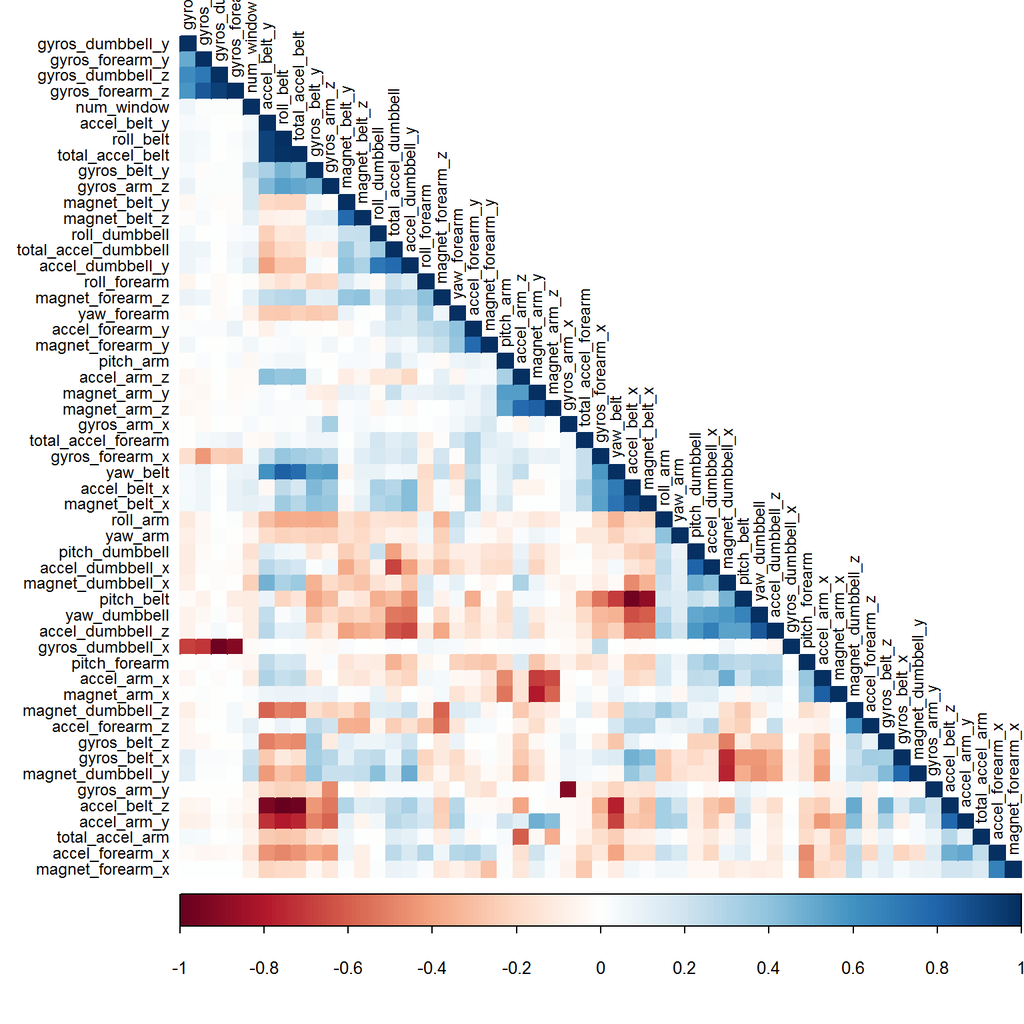

```r
MxCor <- cor(trainCData[, -54])
corrplot(MxCor, order = "hclust", method = "color", type = "lower",
         tl.cex = 0.75, tl.col = rgb(0, 0, 0))
```

High correlated variables are shown in dark blue. But there are quite few correlations. So the PCA will not be applied.

#### **g) Data partitioning**

```r
# Split the clean training data to 70% training and 30% testing set
inTrain <- createDataPartition(trainCData$classe, p = 0.70, list = F)
training <- trainCData[inTrain, ]
testing <- trainCData[-inTrain, ]
```

### **4. Building the Prediction Model**

#### **a) Bulding Decision Tree**

```r
# Decision Tree model
modelDT <- rpart(as.factor(classe) ~ ., data = training, method = "class")
```

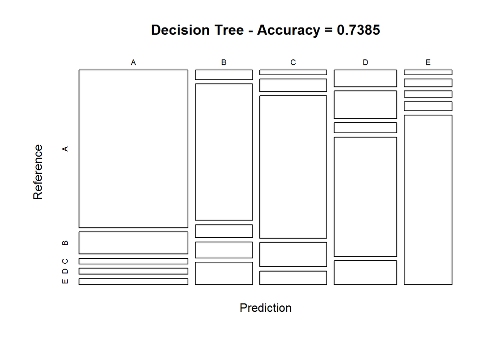

```r
# Prediction on testing dataset
predictDT <- predict(modelDT, testing, type = "class")
# Confusion matrix to see the accuracy
cM2 <- confusionMatrix(predictDT, testing$classe)


# Plot matrix results
plot(cM2$table, col = cM2$byClass,
     main = paste("Decision Tree - Accuracy =",
                  round(cM2$overall['Accuracy'], 4)))
```

The accuracy of the model is 73,85% and the estimated out-of-sample error is 26,15%

#### **b) Generalized Boosted Model**

```r
controlGBM <- trainControl(method = "repeatedcv", number = 5, repeats = 1)
modFitGBM  <- train(classe ~ ., data=training, method = "gbm",
                    trControl = controlGBM, verbose = FALSE)
modFitGBM$finalModel
```

```
## A gradient boosted model with multinomial loss function.
## 150 iterations were performed.
## There were 53 predictors of which 40 had non-zero influence.
```

```r
# prediction on Test dataset
predictGBM <- predict(modFitGBM, newdata=testing)
confMatGBM <- confusionMatrix(predictGBM, testing$classe)
confMatGBM
```

```
## Confusion Matrix and Statistics
##
##           Reference
## Prediction    A    B    C    D    E
##          A 1668   22    0    2    0
##          B    6 1101   10    7    1
##          C    0   16 1014   13    3
##          D    0    0    2  937    9
##          E    0    0    0    5 1069
##
## Overall Statistics
##
##                Accuracy : 0.9837
##                  95% CI : (0.9801, 0.9868)
##     No Information Rate : 0.2845
##     P-Value [Acc > NIR] : < 2.2e-16
##
##                   Kappa : 0.9794
##  Mcnemar's Test P-Value : NA
##
## Statistics by Class:
##
##                      Class: A Class: B Class: C Class: D Class: E
## Sensitivity            0.9964   0.9666   0.9883   0.9720   0.9880
## Specificity            0.9943   0.9949   0.9934   0.9978   0.9990
## Pos Pred Value         0.9858   0.9787   0.9694   0.9884   0.9953
## Neg Pred Value         0.9986   0.9920   0.9975   0.9945   0.9973
## Prevalence             0.2845   0.1935   0.1743   0.1638   0.1839
## Detection Rate         0.2834   0.1871   0.1723   0.1592   0.1816
## Detection Prevalence   0.2875   0.1912   0.1777   0.1611   0.1825
## Balanced Accuracy      0.9954   0.9808   0.9909   0.9849   0.9935
```

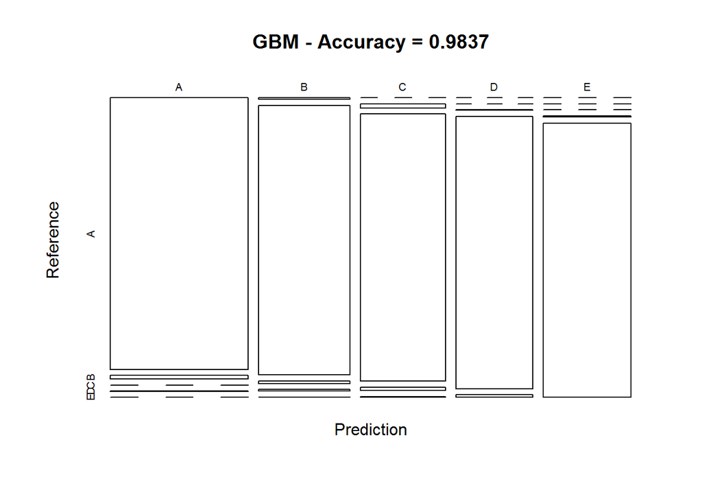

```r
# plot matrix results
plot(confMatGBM$table, col = confMatGBM$byClass,
     main = paste("GBM - Accuracy =", round(confMatGBM$overall['Accuracy'], 4)))
```

The accuracy of the model is 98.37% and the estimated out-of-sample error is 1.63%

#### **c) Random Forest Model**

```r
# Random Forest Model
RFM <- randomForest(as.factor(classe) ~ ., data = training)
# Prediction on testing dataset
predictRFM <- predict(RFM, testing, type = "class")
# Confusion matrix to see the accuracy
cM <- confusionMatrix(predictRFM, testing$classe)
cM
```

```
## Confusion Matrix and Statistics
##
##           Reference
## Prediction    A    B    C    D    E
##          A 1673    2    0    0    0
##          B    0 1136    2    0    0
##          C    0    1 1024    8    0
##          D    0    0    0  955    1
##          E    1    0    0    1 1081
##
## Overall Statistics
##
##                Accuracy : 0.9973
##                  95% CI : (0.9956, 0.9984)
##     No Information Rate : 0.2845
##     P-Value [Acc > NIR] : < 2.2e-16
##
##                   Kappa : 0.9966
##  Mcnemar's Test P-Value : NA
##
## Statistics by Class:
##
##                      Class: A Class: B Class: C Class: D Class: E
## Sensitivity            0.9994   0.9974   0.9981   0.9907   0.9991
## Specificity            0.9995   0.9996   0.9981   0.9998   0.9996
## Pos Pred Value         0.9988   0.9982   0.9913   0.9990   0.9982
## Neg Pred Value         0.9998   0.9994   0.9996   0.9982   0.9998
## Prevalence             0.2845   0.1935   0.1743   0.1638   0.1839
## Detection Rate         0.2843   0.1930   0.1740   0.1623   0.1837
## Detection Prevalence   0.2846   0.1934   0.1755   0.1624   0.1840
## Balanced Accuracy      0.9995   0.9985   0.9981   0.9952   0.9993
```

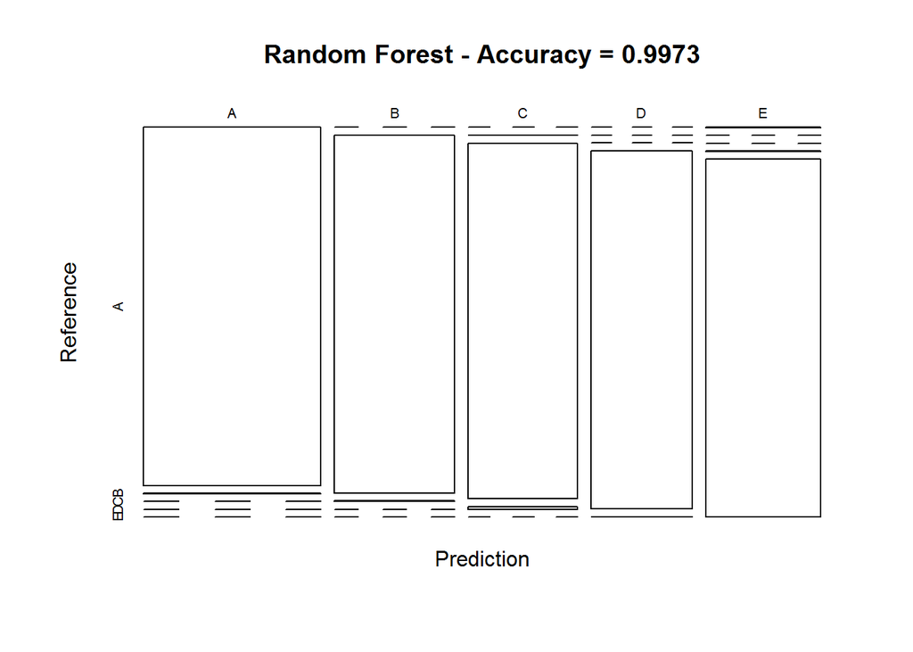

```r
# plot matrix results
plot(cM$table, col = cM$byClass,
     main = paste("Random Forest - Accuracy =",
                  round(cM$overall['Accuracy'], 4)))
```

The accuracy of the model is 99.73% and the estimated out-of-sample error is 0.270%

### **5. Conclusion**

We choose Random Forest Model for our prediction because his Accuracy is the best 0.9973 among the three models.

The expected out-of-sample error from our choice is: 100 - 0.9973 = 0.270%

```r
# predict the `class` of the tesdDFclean data
predict(RFM, newdata = testCData)
```

```
##  1  2  3  4  5  6  7  8  9 10 11 12 13 14 15 16 17 18 19 20
##  B  A  B  A  A  E  D  B  A  A  B  C  B  A  E  E  A  B  B  B
## Levels: A B C D E
```